# Reproducible Research: Course Project 1

Ola Aduroja

October 17, 2020

- This is a document that demonstrates the use of R Markdown to produce an HTML document containing both the codes and the results.

**1. Code for reading in the dataset and/or processing the data**

There is need to first read all the required Libraries (knitr, ggplot2 and dplyr) into R memory

```r
knitr::opts_chunk$set(echo = TRUE)
# Load all required Libraries
library(knitr)
library(ggplot2)
library(dplyr)
```

Download the zip file, extract and load the activity.csv from the Zip file. The Data file activity.csv is in a compressed file and will have to be extracted

```r
temporary <- tempfile()
download.file("https://d396qusza40orc.cloudfront.net/repdata%2Fdata%2Factivity.zip", temporary, mode="wb")
unzip(temporary, "activity.csv")
activity <- read.csv("activity.csv",header=T)
unlink(temporary)
```

The mean total number of steps taken per day Ignoring the missing values is calculated by first computing the aggregate number of steps taken per day. This is done below.

```r
totalstepsperday <- aggregate(steps ~ date, data = activity, FUN = sum, na.rm = TRUE)
```

The presented date format of the dates in the activity.csv is converted before plotting the Histogram of the total number of steps taken per day.

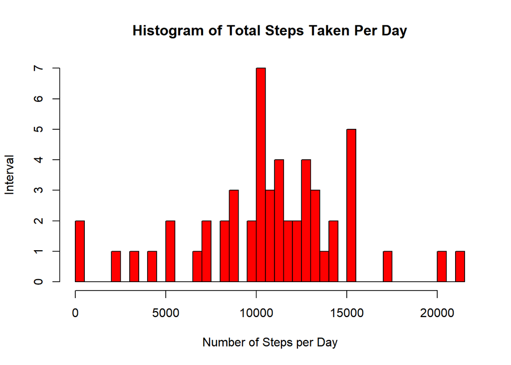

```r
## converting dates to Y-M-D format
activity$date <- as.Date(activity$date, "%Y-%m-%d")

## calculate steps as it relates to date using.
hist(totalstepsperday$steps,
     main="Histogram of Total Steps Taken Per Day",
     xlab="Number of Steps per Day",
     ylab = "Interval",
     col="red",
     breaks=50)
```

Calculate and report the mean and median total number of steps taken per day.

```r
# mean of total steps per day

meanTotalSteps <- mean(totalstepsperday$steps)
meanTotalSteps
```

```
## [1] 10766.19
```

```r
# median of total steps per day

medianTotalSteps <- median(totalstepsperday$steps)
medianTotalSteps
```

```
## [1] 10765
```

The average daily activity pattern. A time series plot (i.e. type = "l") of the 5-minute interval (x-axis) and the average number of steps taken, averaged across all days (y-axis)

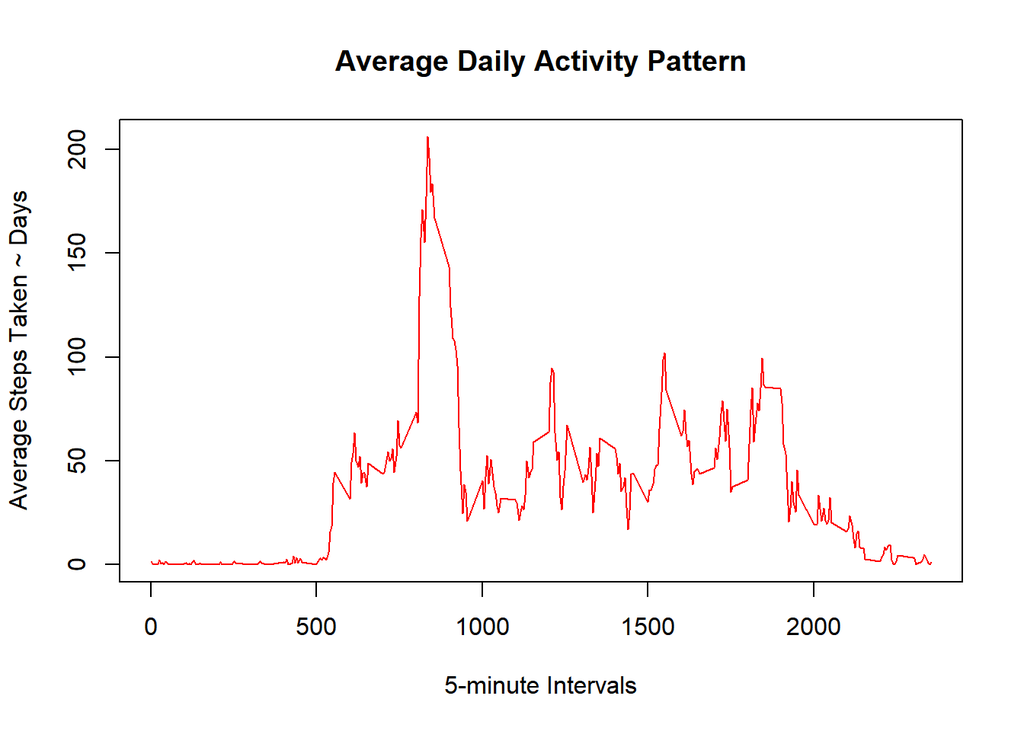

```r
## five minute average using steps to interval - FUN = mean instead of sum
intervalfivemin <- aggregate(steps ~ interval, data = activity, FUN = mean, na.rm = TRUE)

## Plot line chart
plot(x = intervalfivemin$interval,
     y = intervalfivemin$steps,
     type = "l",
     col = "red",
     xlab = "5-minute Intervals",
     ylab = "Average Steps Taken ~ Days",
     main = "Average Daily Activity Pattern")
```

Which 5-minute interval, on average across all the days in the dataset, contains the maximum number of steps

```r
maximumsteps <- intervalfivemin$interval[which.max(intervalfivemin$steps)]
maximumsteps
```

```
## [1] 835
```

```r
# Calculate and report the total number of missing values in the dataset (i.e. the total number of rows with NAs)

# Replace NA values with the mean results for five minute intervals Create a new dataset that is equal to the original dataset but with the missing data filled in

activity2 <- activity
nas <- is.na(activity2$steps)
avg_interval <- tapply(activity2$steps, activity2$interval, mean, na.rm=TRUE, simplify = TRUE)
activity2$steps[nas] <- avg_interval[as.character(activity2$interval[nas])]
names(activity2)
```

[output not shown]

```
## [1] "steps"    "date"     "interval"
```

```r
sum(is.na(activity2))
```

```
## [1] 0
```

Histogram of the total number of steps taken each day and Calculate and report the mean and median total number of steps taken per day.

Confirm whether these values differ from the estimates from the values with the Missing values plotted. What is the impact of imputing missing data on the estimates of the total daily number of steps?

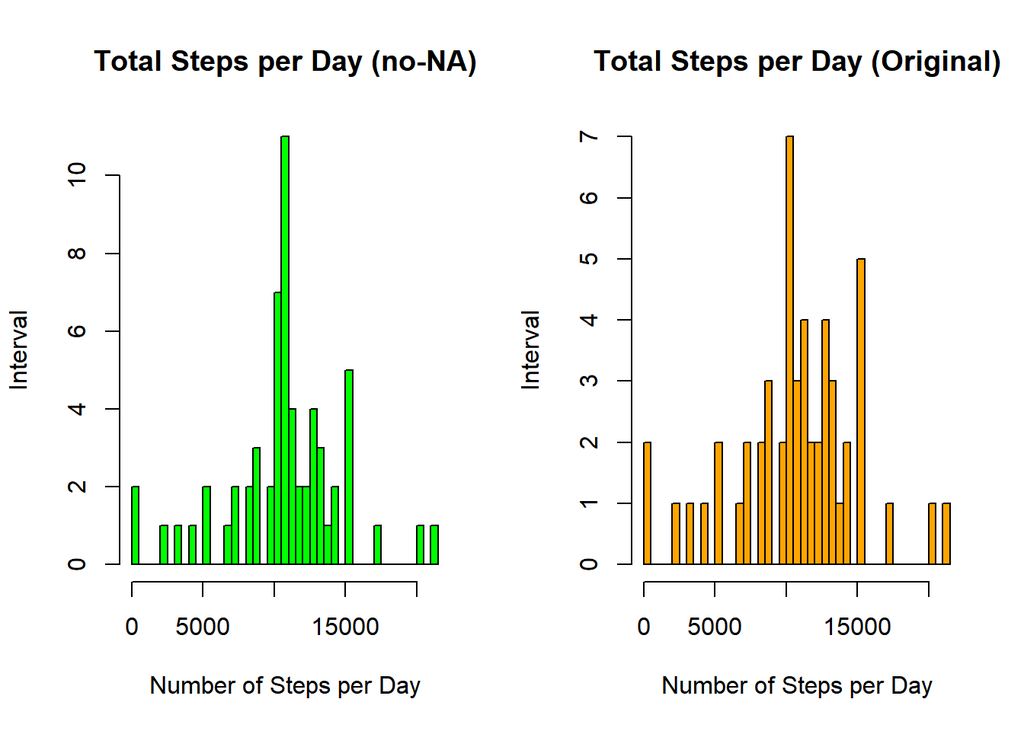

```r
# The Plot
# Setting up the pannel for one row and two columns
par(mfrow=c(1,2))

## Similar analysis without NAs now
totalstepsperday2 <- aggregate(steps ~ date, data = activity2, FUN = sum, na.rm = TRUE)

# Histogram without the NA values
hist(totalstepsperday2$steps,
     main = "Total Steps per Day (no-NA)",
     xlab = "Number of Steps per Day",
     ylab = "Interval",
     col="green",
     breaks=50)
# Histogram with the orginal dataset
hist(totalstepsperday$steps,
     main="Total Steps per Day (Original)",
     xlab="Number of Steps per Day",
     ylab = "Interval",
     col="orange",
     breaks=50)
```

```r
# Reset the panel
par(mfrow=c(1,1))

# What is the impact of imputing data?
summary(totalstepsperday)
```

```
##      date               steps
##  Length:53          Min.   :   41
##  Class :character   1st Qu.: 8841
##  Mode  :character   Median :10765
##                     Mean   :10766
##                     3rd Qu.:13294
##                     Max.   :21194
```

```r
summary(totalstepsperday2)
```

```
##       date                steps
##  Min.   :2012-10-01   Min.   :   41
##  1st Qu.:2012-10-16   1st Qu.: 9819
##  Median :2012-10-31   Median :10766
##  Mean   :2012-10-31   Mean   :10766
##  3rd Qu.:2012-11-15   3rd Qu.:12811
##  Max.   :2012-11-30   Max.   :21194
```

```r
## Add the new weekend/weekday field
activity2<- activity2%>%
  mutate(typeofday= ifelse(weekdays(activity2$date)=="Saturday" | weekdays(activity2$date)=="Sunday", "Weekend", "Weekday"))

## Plot - Line chart
intervalfivemin2<- aggregate(steps ~ interval, data = activity2, FUN = mean, na.rm = TRUE)
head(intervalfivemin2)
```

```
##   interval     steps
## 1        0 1.7169811
## 2        5 0.3396226
## 3       10 0.1320755
## 4       15 0.1509434
## 5       20 0.0754717
## 6       25 2.0943396
```

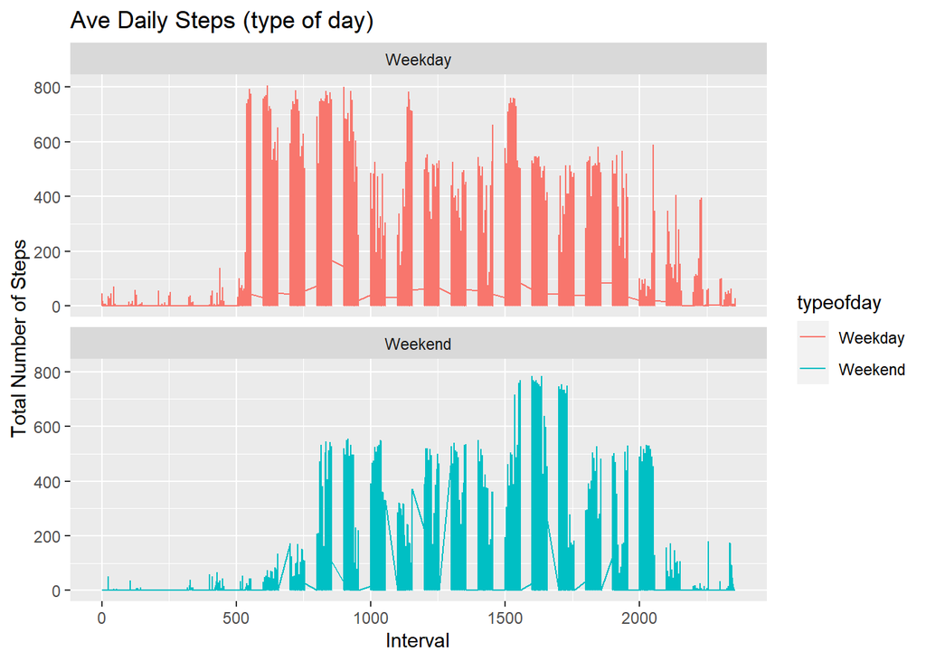

```r
# Use ggplot2 Plotting System
ggplot(activity2, aes(x =interval , y=steps, color=typeofday)) +
  geom_line() +
  labs(title = "Ave Daily Steps (type of day)", x = "Interval", y = "Total Number of Steps") +
  facet_wrap(~ typeofday, ncol = 1, nrow=2)
```